# R tutorial for analysing AMR phenotypic data

The example below demonstrates how to generate a mirrored barplot similar to that in presented in Mughini-Gras 2019 Lancet Planet Health 2019: 3: 357–69.

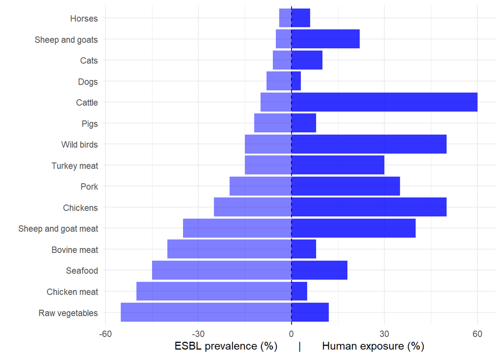

```r
#Generate some example data
data <- tibble(
  Source = c("Wild birds", "Chicken meat", "Bovine meat",
             "Sheep and goat meat", "Pork", "Turkey meat", "Seafood", "Raw vegetables", "Chickens",
             "Cattle", "Sheep and goats", "Pigs", "Dogs", "Cats", "Horses"),
  Prevalence = c(15, 50, 40, 35, 20, 15, 45, 55, 25, 10, 5, 12, 8, 6, 4),
  HumanExposure = c(50, 5, 8, 40, 35, 30, 18, 12, 50, 60, 22, 8, 3, 10, 6)
)

# Convert prevalence to negative values for mirroring
data <- data %>%
  mutate(Prevalence = -Prevalence)

# Create the mirrored bar chart  with no colour gradient
ggplot(data) +
  geom_col(aes(x = Prevalence, y = reorder(Source, Prevalence)), fill = "blue", alpha = 0.5) +  # Left side
  geom_col(aes(x = HumanExposure, y = reorder(Source, Prevalence)), fill = "blue", alpha = 0.8) +
  geom_vline(xintercept = 0, linetype = "dashed") +  # Center line
  labs(x = "ESBL prevalence (%)       |       Human exposure (%)",
       y = "") +
  theme_minimal()
```

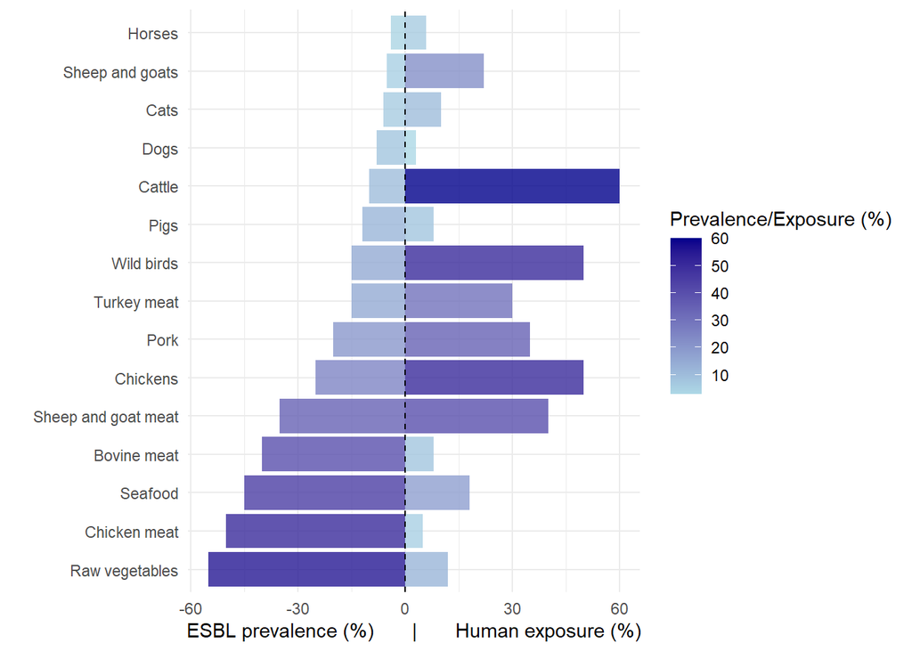

```r
#Create the mirrored bar chart with a colour gradient
ggplot(data) +
  geom_col(aes(x = Prevalence, y = reorder(Source, Prevalence), fill = -Prevalence), alpha = 0.8) +  # Left side
  geom_col(aes(x = HumanExposure, y = reorder(Source, Prevalence), fill = HumanExposure), alpha = 0.8) +  # Right side
  geom_vline(xintercept = 0, linetype = "dashed") +  # Center line
  scale_fill_gradient(low = "lightblue", high = "darkblue") +  # Gradient from light to dark blue
  labs(x = "ESBL prevalence (%)       |       Human exposure (%)",
       y = "",
       fill = "Prevalence/Exposure (%)") +
  theme_minimal()
```

*Upset plots*

The example below illustrates how to generate an upset plot. Upset plots are used to visualise intersections of data sets (e.g. as an alternative to Venn diagrams). For further information on upset plots see https://jokergoo.github.io/ComplexHeatmap-reference/book/upset-plot.html.

```r
library(ComplexUpset)

dat <- read_csv("data/upset.csv")
#Generate a character vector with the antibiotic abbreviations
abs <- c("CTX","T", "CIP", "S")

#Assign names to the elements of the antibiotics vector
names(abs) <- abs
abs
```

```
##   CTX     T   CIP     S
## "CTX"   "T" "CIP"   "S"
```

```r
str(dat)
```

```
## spc_tbl_ [1,388 × 6] (S3: spec_tbl_df/tbl_df/tbl/data.frame)
##  $ SampleID: num [1:1388] 1 2 3 4 5 6 7 8 9 10 ...
##  $ Region2 : num [1:1388] 1 1 1 1 1 1 1 1 1 1 ...
##  $ S       : num [1:1388] 0 0 0 0 0 0 0 0 0 0 ...
##  $ T       : num [1:1388] 0 0 0 0 0 0 0 0 0 0 ...
##  $ CTX     : num [1:1388] 0 1 0 0 0 0 0 0 0 0 ...
##  $ CIP     : num [1:1388] 0 0 0 0 0 0 0 0 0 0 ...
##  - attr(*, "spec")=
##   .. cols(
##   ..   SampleID = col_double(),
##   ..   Region2 = col_double(),
##   ..   S = col_double(),
##   ..   T = col_double(),
##   ..   CTX = col_double(),
##   ..   CIP = col_double()
##   .. )
##  - attr(*, "problems")=<externalptr>
```

```r
#Convert the Region2 column to a factor
dat$Region2 <- factor(dat$Region2)
str(dat)
```

```
## spc_tbl_ [1,388 × 6] (S3: spec_tbl_df/tbl_df/tbl/data.frame)
##  $ SampleID: num [1:1388] 1 2 3 4 5 6 7 8 9 10 ...
##  $ Region2 : Factor w/ 5 levels "1","2","3","4",..: 1 1 1 1 1 1 1 1 1 1 ...
##  $ S       : num [1:1388] 0 0 0 0 0 0 0 0 0 0 ...
##  $ T       : num [1:1388] 0 0 0 0 0 0 0 0 0 0 ...
##  $ CTX     : num [1:1388] 0 1 0 0 0 0 0 0 0 0 ...
##  $ CIP     : num [1:1388] 0 0 0 0 0 0 0 0 0 0 ...
##  - attr(*, "spec")=
##   .. cols(
##   ..   SampleID = col_double(),
##   ..   Region2 = col_double(),
##   ..   S = col_double(),
##   ..   T = col_double(),
##   ..   CTX = col_double(),
##   ..   CIP = col_double()
##   .. )
##  - attr(*, "problems")=<externalptr>
```

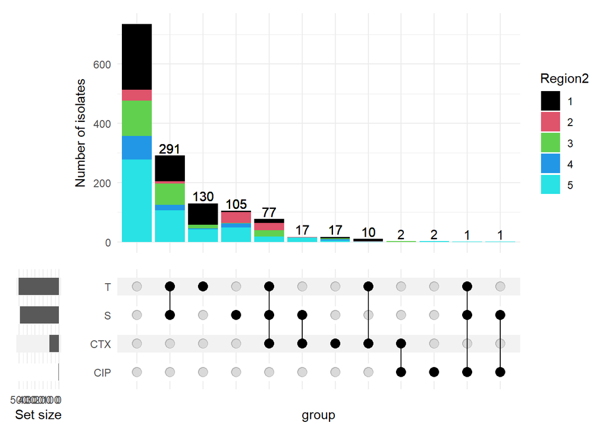

```r
#Create a colour
myPalette <- palette(c( "#1F77B4", "#2CA02C", "#9467BD", "#E377C2", "#7F7F7F")) #set colours to use

# constructing the plot with ggplot2

upset(dat,abs, #create an upset plot with the dataframe dat and the intersections defined by the abs vector
      base_annotations=list('Intersection size'=intersection_size( #plots the size of each intersection
      counts=TRUE,mapping=aes(fill=Region2)) #count the number of elements in each intersection color bars based on region
    + geom_bar(stat="identity") #use actual values
    + ylab('Number of isolates') #yaxi label
    + labs(fill = "Region2")), #label legend
  width_ratio=0.1 #width of intersecton bars
  ) & scale_fill_manual(values = myPalette)
```

*Visualising pairwise relationships*

The code below was adapted by Patrick Biggs and Natalia Gonzalez from https://stackoverflow.com/questions/20872133/using-stat-binhex-with-ggpairs

It generates a multi-panel grid plot with a density plot (showing the data distribution) on the diagonal, correlation values in the upper right triangle and hexbin density plots in the lower left triangle.

```r
#Load libraries
library(hexbin)
library(GGally)
```

```r
library(ggcorrplot)

#Read in data
c <- read_csv(("data/Ecoli_Complete.csv"))
#Look at the structure of the data
str(c)
```

```
## spc_tbl_ [1,145 × 9] (S3: spec_tbl_df/tbl_df/tbl/data.frame)
##  $ IsolateID: num [1:1145] 1 2 3 4 5 6 7 8 9 10 ...
##  $ AUG      : num [1:1145] 18.9 18.2 16.8 16.4 18.4 ...
##  $ CAZ      : num [1:1145] 23.6 17.6 21.6 21 24.4 24.8 21.7 24.5 23.5 18.6 ...
##  $ CHL      : num [1:1145] 20.8 19.9 21.9 6.6 20.8 20.6 20.1 20.8 16.6 20.8 ...
##  $ CIP      : num [1:1145] 25.8 25 30.3 29.5 26.7 27.5 25.8 24.7 24.5 25.3 ...
##  $ CTX      : num [1:1145] 25.3 26.8 25.9 25.4 26.4 25.5 21.6 29.2 23.6 20.8 ...
##  $ STR      : num [1:1145] 12.3 13.8 13.9 6.6 6.6 6.6 12.4 13 14.4 6.6 ...
##  $ TET      : num [1:1145] 18.6 19.2 6.6 6.6 6.6 6.6 17.3 20.3 6.6 6.6 ...
##  $ TS       : num [1:1145] 21.2 20.7 6.6 18 6.6 6.6 21.9 20.7 22.6 6.6 ...
##  - attr(*, "spec")=
##   .. cols(
##   ..   IsolateID = col_double(),
##   ..   AUG = col_double(),
##   ..   CAZ = col_double(),
##   ..   CHL = col_double(),
##   ..   CIP = col_double(),
##   ..   CTX = col_double(),
##   ..   STR = col_double(),
##   ..   TET = col_double(),
##   ..   TS = col_double()
##   .. )
##  - attr(*, "problems")=<externalptr>
```

```r
summary(c)
```

```
##    IsolateID         AUG             CAZ             CHL             CIP
##  Min.   :   1   Min.   : 6.60   Min.   :14.50   Min.   : 6.60   Min.   :22.80
##  1st Qu.: 287   1st Qu.:18.30   1st Qu.:23.50   1st Qu.:19.50   1st Qu.:28.90
##  Median : 573   Median :19.50   Median :25.00   Median :21.00   Median :30.90
##  Mean   : 573   Mean   :19.32   Mean   :24.99   Mean   :20.89   Mean   :31.07
##  3rd Qu.: 859   3rd Qu.:20.70   3rd Qu.:26.60   3rd Qu.:22.30   3rd Qu.:33.30
##  Max.   :1145   Max.   :29.40   Max.   :36.90   Max.   :30.40   Max.   :42.70
##       CTX             STR             TET              TS
##  Min.   :16.80   Min.   : 6.60   Min.   : 6.60   Min.   : 6.60
##  1st Qu.:26.10   1st Qu.: 8.70   1st Qu.: 6.60   1st Qu.:14.70
##  Median :28.20   Median :15.20   Median : 6.60   Median :23.00
##  Mean   :28.12   Mean   :13.32   Mean   :12.68   Mean   :20.36
##  3rd Qu.:30.00   3rd Qu.:16.60   3rd Qu.:18.90   3rd Qu.:25.70
##  Max.   :43.50   Max.   :26.80   Max.   :30.10   Max.   :33.00
```

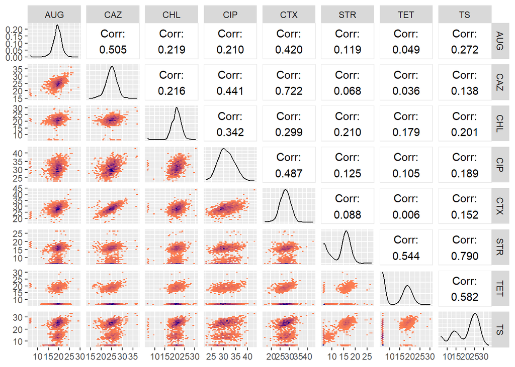

```r
#delete the first column, leaving the numeric values.
c <- c[-1]


## Remove rows with NA values
c_clean <- na.omit(c)


## Make function for generating scatterplots and correlation values for pairs of antibiotics
ggpairs_hex <- function(df, hexbins = 30) { #define the function named ggpairs_hex which will take the the arguments df and hexbins. The default value for hexagonal binnng is 30
  # REF: https://stackoverflow.com/questions/20872133/using-stat-binhex-with-ggpairs
  p <- ggpairs(df, lower="blank", #the lower triangle (below the diagonal) is blank
               upper = list(continuous = wrap("cor", color = "black", stars = FALSE))) #ggpairs (from the package GGally) the upper triangle of the grid displays the (Pearson) correlation value in black. wrap allows multiple parameters to pass to the "cor" function
  seq <- 1:ncol(df) #generate vector called seq with the numbers 1 through to the number of columns
  for (x in seq) #loop over the x-axis variables
    for (y in seq) #loop over y-axis variable
      if (y>x)  #only fill the upper triangle
        p <- putPlot(p, #putplot() function used to insert the new plot below into the lower triangle position putPlot(ggpairs_object, new_plot, row, col)
                     ggplot(df, aes_string(x=names(df)[x], y=names(df)[y])) + #assign x and y variables
                       stat_binhex(bins = hexbins) + #Create a hexbin  density plot (instead of a scatter plot) 2D histogram
                       scale_fill_gradient(low='coral', high='darkblue'), #Colour points from light to dark
                     y,  x)
  return(p)
}

#Run the function with your dataframe
ggpairs_hex(c_clean)
```

$\\$

## Day 5 - Local and Healthy Chickens Comparison

1. Generate tables and plots to compare local chicken AST results with healthy chicken.
2. Finish generating plots from your own data.
3. Present plots to the group

$\\$

**Useful links to other tutorials and resources**

Links to the AMR R package https://cran.r-project.org/web/packages/AMR/AMR.pdf

See https://bookdown.org/amy_yarnell/T32-book/selected-glossary-of-r-terminology.html for some more definitions.

For dates and times see https://r4ds.had.co.nz/dates-and-times.html

https://r-graph-gallery.com/

Advanced R by Hadley Wickham https://adv-r.hadley.nz/index.html R for Data Science by Hadley Wickham https://r4ds.hadley.nz/

Berends et al. AMR: An R Package for Working with Antimicrobial Resistance Data doi: 10.18637/jss.v104.i03